# Kusama Auctions 1-5: Report

Jonas Gehrlein

08/13/2021

# Introduction

The launch of the first rotation of parachain slot auctions on Kusama marks a major milestone in achieving a scalable, decentralized, and interoperable future. Several professional teams, having received support from the Web3 Grants Program to develop their projects, were ready to launch and compete for one of the first five ever available parachain slots. This post recaps what happened during the first auctions and analyzes the outcomes and their come about and provides important background knowledge on the candle auction and crowdloan mechanisms. Thereby, it uses data available from the Kusama blockchain as well as the results from an anonymous survey that was conducted with fifteen parachain teams prior to the auctions (at the end of March / early April). Further, the last section incorporates estimates gathered throughout verbal interviews with parachain teams about their expectations regarding the future of the parachain slot auctions, especially when the situation arrives where some parachains aim to extend their leases while others seek their first onboarding.

### The Candle Auction: A refresher

Before proceeding with the analysis of the individual auctions, it is good to recapitulate the underlying mechanism. The candle auction is an old auction format from around the 16th century where bidding was allowed until an actual wax candle went out. The uncertainty about the actual ending time of the auction was used to reduce auction sniping, which was already back then known to be an issue. This phenomenon describes the situation that bidders hold back until the last possible moment to squeeze their bid in to not give other participants the chance to react. Many of us probably had similar experiences in the past with online auction formats such as eBay.

The candle auction format was long considered exotic and has not seen much application. However, it has proven beneficial properties when combining it with the blockchain both for avoiding sniping and obtaining efficiency. It is therefore considered to be a suitable mechanism to allocate parachain slots on Polkadot and Kusama. In contrast to the ancient candle auction, the end is determined retrospectively. That means, the auction always has a fixed length, and only after it ends, the actual ending block (“termination block”) is randomly determined. We can mark four important checkpoints to describe the temporal procedure of a candle auction, described in block heights. The following graph illustrates the structure.

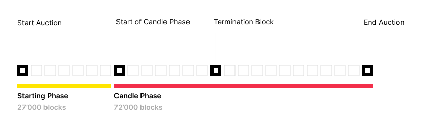

The start and end blocks of the auction determine the fixed length of each auction and give participants certainty about the overall framework. The first phase of the auction, lasting exactly 27,000 blocks (around 45 hours), serves as a grace period where teams and users have time to get an overview of the situation, gather information, and set up their bidding/contributing strategies. The blocks in this phase, while bidding is enabled, are not yet considered by the mechanism, i.e., the termination block cannot fall inside that range. After that, the candle phase (or ending phase) marks the “real” beginning of the auction. Here, figuratively, the candle is lit and this phase lasts for 72,000 blocks (around 5 days). During this phase, the auction could end at any given block with equal probability (i.e., the candle phase has a uniform termination profile) (footnote: More precisely: To reduce storage requirements, only every 20th block can be sampled and be selected as the termination block). Bidding is allowed until the end of the auction. After the official ending, the termination block is computed by using a combination of verified random functions. Calculating the termination block retrospectively ensures that nobody can predict it before or during the auction.

The winning bids that are contained in the termination block are then used to determine the outcome of the auction, while all later bids are discarded. This uncertainty and the possibility that bids are not relevant for the final outcome, incentivizes early bidding and can thereby reduce sniping. To keep potential confusion of participants at a minimum, there can always ever be one active auction at the same time.

### Crowdloan Mechanism

Technically, a crowdloan is a simple module that enables projects to gather tokens for their parachain in a decentralized way. Specifically, tokens are gathered on behalf of the teams, as those remain in the custody of and are secured by the Relay Chain. This means that participation in a crowdloan campaign is trustless for users and they can be certain to receive their contributions back at one of two predefined dates. The first date corresponds to the case where a crowdloan successfully secured a parachain slot. In this case, tokens can be reclaimed by the users at the end of the lease that the crowdloan obtained. In the other case, tokens can be retrieved directly after the (generally short) duration the crowdloan expires. As tokens are reclaimable, the actual costs of users’ contributions, economically speaking, are the opportunity costs that accrue from locking those (e.g., forgone rewards from staking or from using the locked tokens differently). To provide clarity about when users can expect their tokens back in the case that the crowdloan wins a slot, the leasing period that it bids for is fixed. Additionally, the module increases the bid automatically and exactly by the amount and at the time that the contribution is made (footnote: To decrease the storage requirements, those bids are actually only cast on-chain once the candle phase starts). If the crowdloan successfully wins an auction, tokens are automatically locked for the period of time and then released and can be reclaimed by the accounts that contributed. Contributions after the termination block (but before the end of the auction) are still locked, but naturally did not increase the winning bid. Any incentive structure for contributing to the crowdloans are completely organized by the respective crowdloan projects.

## Auction Schedule

After having established the basic concepts, let us dive into the data. In total, the first rotation allocated five parachain slots during June and July 2021. The whole campaign lasted from June 15th and the last auction ended on July 20th. Each auction lasted seven days with a two-day starting and five day candle phase. The following table provides the dates for the four important events of each auction (the same table with the events expressed in their block heights can be found in the Appendix).

|  | Start | End | Start of Candle Period | Date of Termination Block |
| --- | --- | --- | --- | --- |
| Auction 1 | 15.06.2021 | 22.06.2021 | 17.06.2021 | 21.06.2021 |
| Auction 2 | 22.06.2021 | 29.06.2021 | 24.06.2021 | 26.06.2021 |
| Auction 3 | 29.06.2021 | 06.07.2021 | 01.07.2021 | 05.07.2021 |
| Auction 4 | 06.07.2021 | 13.07.2021 | 08.07.2021 | 12.07.2021 |
| Auction 5 | 13.07.2021 | 20.07.2021 | 15.07.2021 | 20.07.2021 |

# Auction Data

All bids were cast by crowdloans (footnote: There were a few non-serious bids from individually controlled accounts, which are discarded from the analysis because of their irrelevance). This was to be expected as 86.7% of projects predicted that they will use crowdloans to raise tokens in the survey. The rest either changed their strategy in the meantime or aim to bid from a user-controlled account in future sequences of auctions. Most projects claimed that their project requires a lease period of at least one year to fully operate, which is why all crowdloans were programmed to bid for the entirety of 8 leasing periods (labeled 13-20), which roughly corresponds to 48 weeks.

## Overview

Already at the time the teams took the survey, they felt ready for the long-awaited start of the parachain slot auctions on Kusama. Ten out of 15 teams indicated that they are aiming to enter the race for the first available slots on Kusama. Most of the teams, in fact, 80%, indicated that they also plan to launch on Polkadot (with 13.3% only on Kusama and 6.7% only on Polkadot). The survey shows that the preparation of the auctions and strategies was a high priority for the teams, as they gave it extensive thought (with an average score of 6.5 of 7). It is therefore not surprising that we saw fierce competition between teams in securing their spot at the Kusama Relay Chain. In total, 18 crowdloans have registered to participate in the auctions and have received contributions during the campaign from 19017 unique accounts. A total number of 1,320,458 KSM was bonded to crowdloans. Hereoff, 1,114,629 KSM has been locked in slots until May 13th, 2022, while the rest can be reclaimed by users, as their chosen crowdloans could not secure a Parachain slot. At the time of the events, from all issued tokens, 47% is locked in staking and 9.9% for crowdloans. Individual accounts contributed on average to 1.8 crowdloans (for more details, see Appendix).

The following table summarizes relevant metrics for the eight projects with the highest locked KSM for crowdloans (the full table is available in the Appendix)).

|  | Number Contributors | Unique Contributors | Sum of Contributions (in KSM) | Average Contribution (in KSM) |
| --- | --- | --- | --- | --- |
| Karura | 20779 | 14164 | 501137.7 | 24.1 |
| Moonriver | 10339 | 5977 | 205935.0 | 19.9 |
| Shiden | 7261 | 4611 | 138457.9 | 19.1 |
| Bifrost | 3126 | 938 | 136817.8 | 43.8 |
| Khala | 4473 | 2759 | 132280.7 | 29.6 |
| Basilisk | 2185 | 1173 | 116805.4 | 53.5 |
| Robonomics | 1564 | 992 | 26981.4 | 17.3 |
| Altair | 1204 | 803 | 20069.0 | 16.7 |

We’ll have a closer look at each auction in the following.

## Auction 1-3

From the very beginning, three strong teams crystallized and consequently it was no surprise that they’d occupy the first three slots on Kusama. Karura took the lead from early on and surpassed all other teams by a large margin. Moonriver started out lower than their competitors but was able to quickly surpass Shiden even before the candle phase started. Shiden, secured the third spot. In total, 501,138 KSM was bonded for Karura, 205,935 KSM for Moonriver and 138,458 KSM for Shiden.

## Auction 4

The winning bid constantly changed before the candle phase started. However, Khala could secure large contributions right in time with the start of the candle period and held the winning bid during all blocks. This can mainly be attributed to the candle mechanism, where it is important for teams that want to maximize their winning probability to secure the lead throughout the whole candle phase. Bifrost was, indeed, not able to catch up and therefore Khala won the fourth Parachain slot on Kusama. In total, 132,280.7 KSM was bonded for their crowdloan´.

Naturally, Bifrost was still in the race for the fifth and last slot and contributions kept increasing after the end of the fourth auction.

## Auction 5

### The Impact of the Candle Mechanism

As explained in the introduction, the candle auction is composed of two different stages, namely the starting and candle phase. The latter is further divided (retrospectively), into a period that falls before and after the termination block. This mechanism could lead to the situation that the highest bidder at the end of the auction does not necessarily win the auction, because their winning bid is discarded if it falls into the range after the termination block. All tokens that are contributed to a winning crowdloan during the whole auction would still be locked for the entirety of the respective leasing period. This means that we could observe some inefficiency, both in determining the winner and in locking tokens that did not contribute to a higher winning bid. In the next table, the sum of contributions is separated by the respective phases. Additionally, the table shows when the termination block occurred as a percent of the whole candle phase.

| Name | Pre-Candle Phase | Candle Phase (Pre-Termination) | Candle Phase (Post-Termination) | Termination Time (in % of Candle Phase) |
| --- | --- | --- | --- | --- |
| Karura | 451,515 KSM | 40,238 KSM | 9,385 KSM | 74% |
| Moonriver | 158,898 KSM | 17,587 KSM | 29,450 KSM | 47% |
| Shiden | 102,039 KSM | 34,985 KSM | 1,434 KSM | 79% |
| Khala | 83,039 KSM | 46,966 KSM | 2,276 KSM | 85% |
| Bifrost | 90,544 KSM | 45,517 KSM | 757 KSM | 97% |

In general, the auction mechanism aims to incentivize individual bidders to bid early. It is difficult to assess how it influences the contribution pattern of many users that are bonding their tokens for crowdloans. Further, as tokens were used to bid in consecutive auctions, it is not clear whether we would have seen the same bidding dynamics in single auctions. Another confounding factor is that some teams provided stronger platform rewards for early contribution, which blend with the incentives provided by the candle mechanism.

However, taking the data of the first auction as a proxy, it seems that incentives to act early did work as most of the contributions were made in the pre-candle phase. Additionally, the vast amount of contributions for every crowdloan was made in the starting period of the auction. It therefore seems that the candle mechanism successfully incentivized early bidding. There was, however, some amount contributed after the termination block which could have led to inefficiencies.

## Summary

That being said, we can still take a closer look at the results with those concepts in mind. If we take the total backing for the crowdloans as a proxy for the valuation that would be created by the respective projects occupying those slots, we can summarize that the five teams with the highest backing received the five available slots. Specifically, the candle mechanism did not lead to the case where a slot was allocated to a project that had less backing at the end of the campaign than another project that did not obtain a slot. The second property of evaluating standard auctions, revenue, is also hard to assess in this special case. As there is no entity that could be considered an auctioneer, there is nobody directly benefiting from bids, and therefore we cannot argue of any revenue created.

Another observation is that especially for slot 1 and 2, an excessive number of tokens was bonded (compared to the second-highest bid). From the theoretical perspective, this could be considered as not optimal, because more tokens than necessary were bonded to win the slots. However, in reality there are some influences to account for that, especially during this *onboarding phase*, where all teams aimed for their inception. First, the distribution characteristics of the crowdloans are more important than to minimize the winning bid in the auction. It was simply more useful to distribute the tokens to as many supporters as possible in order to benefit from future network effects and to build an involved community. Second, more backing signals a higher quality and value of the project to the ecosystem. Third, the opportunity costs of the excess of bonded tokens, was shared among the contributors, who received compensating platform rewards. Those factors outweigh the importance of obtaining a slot as cheaply as possible. We will see in the next chapter that this might change in the future.

In conclusion, the outcome of the auctions were largely shaped by the overwhelming use of crowdloans and their specific implementation. While, from a purely theoretical perspective, we observed some odd factors, most of them can be accounted for by the nature of the onboarding phase. Generally, the candle mechanism seems to have incentivized earlier bidding (or contributing) and the highest backed teams won their respective slots.

# The Future

With more auctions upcoming, it is worthwhile to consider how things could develop in the future. Naturally, it will eventually change from a situation with no active parachains, to a situation where some parachains need to sustain operation by extending their leases, while others aim to be onboarded for the first time. This will lead to more dynamic events where the two main aspects affected in the campaigns are the *contribution mechanisms* themselves and how tokens are then used in *auction bidding*. Currently the spotlight was on the contribution mechanism, i.e., the crowdloans, which already came with a pre-built bidding mechanism. However, we might see the bidding aspect become increasingly important and therefore requires to be more dynamic. That is due to the fact that the economic incentives for projects that seek to extend their leases will be different from those that need to be onboarded for the first time. Additionally, the maturing ecosystem with the above mentioned functionalities, enabled by interoperable chains, offer new possibilities for more dynamic bidding strategies. Let us disentangle the two mechanisms and look at them individually.

## Contribution Mechanism

Most ambitious projects require external support long before the final product is even close to completion. This holds true for crypto- as well as traditional markets. In previous token generation events on other chains, generally all contributed tokens were collected at a premature state and their ownership was fully transferred to the founding teams. This often led to the case that the work almost immediately stopped, the development stalled and supporters endured large losses.

In contrast to that, crowdloans are a trustless and decentralized device to enable the community to vouch for their most favoured projects, while the ownership of the tokens remain with the trusted Relay Chain. In return, teams receive the chance to profit from the valuable infrastructure that has been built around the Kusama and Polkadot network and start delivering on their vision. Crowdloans, therefore, are an innovative way to tackle the underlying incentive problem that occurs in this situation. In some sense, it helps to bootstrap the projects, while incentivizing ongoing effort, as teams want to prove that they have a meaningful place in the ecosystem. The scarce nature of the parachain slots ensures healthy competition in the future and helps to find and filter the most suited projects. This novel contribution mechanism will improve the overall quality of the ecosystem, making it a healthier environment where users can feel more comfortable supporting new projects.

Having spoken to a few leading parachain teams, it is clear that sourcing tokens from the community remains an important part of their economics in the future. Aside from the fact that the burden of opportunity costs can be shared, teams especially enjoy it as a mechanism to efficiently distribute their native token to a large crowd of supporters. As teams are innovative, they are already looking for suitable alternatives of contribution mechanisms to incorporate into their infrastructure. One reasonable direction is a parachain native variation of the crowdloan pallet that leverages the interoperability of chains. For example, users could deposit their parachain native token to a smart-contract that automatically exchanges those, via a decentralized exchange (DEX) parachain, to Relay Chain tokens (i.e., KSM or DOT). The smart-contract could then automatically use those tokens to bid in the auction. In addition to the parachain’s native tokens, with upcoming bridges to Ethereum and Bitcoin, it is even possible that the smart-contract could use ETH (and erc20 tokens) and BTC.

In the survey, teams claimed to aim for a ratio of own tokens to crowdsourced tokens of on average 21% already in the first auctions. This percentage of non-community tokens will likely need to increase in the future, as it becomes increasingly difficult to offer platform rewards for contributors, as the initial supply will eventually be fully distributed. Teams further expressed to extend on this hybrid approach where tokens are both sourced from the community and supported by the team’s own treasury. Similar to the smart-contract solution described before, parachains might evolve into decentralized autonomous organisations (DAOs), that raise tokens during their operation and accumulate those within their on-chain treasuries. Eventually, in order to secure preservation, the chains might start to accumulate relay chain tokens with that to extend their leases. That means, the chains themselves are increasingly becoming self-sufficient.

## Auction Bidding

As explained before, the *onboarding phase* is a unique situation in the network, where other factors are more important than to minimize the winning bid. Therefore, we saw the focus on maximizing the bonded tokens rather than optimal bidding under the auction mechanism itself. However, once the network reaches the *extension phase* some active parachains need to secure consecutive leases, competing with new projects that aim for their first onboarding. By then, the ending period of one slot will likely overlap with lease periods of several other slots. Then, it becomes increasingly useful to strategically evaluate which auctions to participate in. It would even make sense to withdraw from one auction, when bids are getting too high, just to join bidding in another. In such a situation, flexible bidding, i.e., minimizing the own winning bid, is an important factor to efficiently sustain the parachain. While 27% of teams already mentioned in the survey that they will switch to some private form of bidding after they obtained their first slot, improved capabilities in the ecosystem might lead to new forms of auction participation mechanisms. To take the example of parachain native pallets of crowdloans, teams are free to abstract the bidding mechanism from the bonding mechanism and delegate it to specific entities (individuals, smart-contracts or the council), that aim for optimal bidding. This means that with a growing number of available slots and active parachains, the candle auction mechanism comes to fruition in the near future and increases in its importance.

# Appendix

## Events of auctions expressed in block heights

|  | Start | End | Start Candle Period | Termination Block |
| --- | --- | --- | --- | --- |
| Auction 1 | 7924237 | 8023773 | 7951237 | 8004557 |
| Auction 2 | 8024552 | 8123989 | 8051552 | 8085863 |
| Auction 3 | 8124516 | 8224041 | 8151516 | 8209096 |
| Auction 4 | 8224581 | 8324128 | 8251581 | 8313301 |
| Auction 5 | 8324750 | 8423750 | 8351750 | 8421690 |

## Full table of crowdloans

|  | Number Contributors | Unique Contributors | Sum of Contributions | Average Contribution |
| --- | --- | --- | --- | --- |
| Karura | 20779 | 14164 | 501138 | 24.1 |
| Moonriver | 10339 | 5977 | 205935 | 19.9 |
| Shiden | 7261 | 4611 | 138458 | 19.1 |
| Bifrost | 3126 | 938 | 136818 | 43.8 |
| Khala | 4473 | 2759 | 132281 | 29.6 |
| Basilisk | 2185 | 1173 | 116805 | 53.5 |
| Robonomics | 1564 | 992 | 26981 | 17.3 |
| Altair | 1204 | 803 | 20069 | 16.7 |
| Polkasmith | 357 | 278 | 17830 | 49.9 |
| Genshiro | 1078 | 673 | 8104 | 7.5 |
| Crust | 936 | 554 | 7208 | 7.7 |
| Sakura | 430 | 173 | 4703 | 10.9 |
| Darwinia | 445 | 387 | 3012 | 6.8 |
| Loom Network | 22 | 19 | 645 | 29.3 |
| Subgame | 79 | 74 | 292 | 3.7 |
| Mars | 63 | 58 | 161 | 2.6 |
| Kpron | 18 | 17 | 16 | 0.9 |
| HLjYi | 6 | 6 | 3 | 0.6 |

### Full table of number of contributions per account

| unique_contributions | number_accounts |
| --- | --- |
| 1 | 12147 |
| 2 | 3385 |
| 3 | 1690 |
| 4 | 796 |
| 5 | 413 |
| 6 | 275 |
| 7 | 111 |
| 8 | 61 |
| 9 | 48 |
| 10 | 36 |
| 11 | 17 |
| 12 | 11 |
| 13 | 10 |
| 14 | 5 |
| 15 | 4 |
| 16 | 3 |
| 17 | 4 |
| 18 | 1 |